# R Programming (Code Supplement)

## Hypothesis Testing

Hypothesis tests are valuable tools for discovering differences in datasets and evaluating relationships between variables.

```r
# t-tests

# Is fertility very different in provinces with above-median % of men in Agriculture
swiss$majority_agg <- swiss$Agriculture > median(swiss$Agriculture)
t.test(Fertility ~ majority_agg, data = swiss)
```

```
##
##  Welch Two Sample t-test
##
## data:  Fertility by majority_agg
## t = -1.3928, df = 31.595, p-value = 0.1734
## alternative hypothesis: true difference in means between group FALSE and group TRUE is not equal to 0
## 95 percent confidence interval:
##  -13.808645   2.596949
## sample estimates:
## mean in group FALSE  mean in group TRUE
##            68.80526            74.41111
```

```r
#  Let's create this feature for every variable (we'll re-use it)

#=== Drop that majority_agg feature
swiss$majority_agg <- NULL

#=== Create the binary columns
x_var_names <- names(swiss)[names(swiss) != "Fertility"]
for (var_name in x_var_names) {

    bin_var_name <- paste0(var_name, "_above_median")
    swiss[, bin_var_name] <- swiss[, var_name] > median(swiss[, var_name])

    # Remember to give the test set these new features!
    swissTestDF[, bin_var_name] <- swissTestDF[, var_name] > median(swiss[, var_name])
}
print(head(swissTestDF, 5))
```

```
##              Fertility Agriculture Examination Education Catholic
## ValdeTravers      67.6        18.7          25         7     8.65
## Yverdon           65.4        49.5          15         8     6.10
## Neuveville        76.9        43.5          17        15     5.16
## Orbe              57.4        54.1          20         6     4.20
## Aubonne           66.9        67.5          14         7     2.27
##              Infant.Mortality Agriculture_above_median Examination_above_median
## ValdeTravers             19.5                    FALSE                     TRUE
## Yverdon                  22.5                    FALSE                    FALSE
## Neuveville               20.6                    FALSE                     TRUE
## Orbe                     15.3                    FALSE                     TRUE
## Aubonne                  19.1                     TRUE                    FALSE
##              Education_above_median Catholic_above_median
## ValdeTravers                  FALSE                 FALSE
## Yverdon                       FALSE                 FALSE
## Neuveville                     TRUE                 FALSE
## Orbe                          FALSE                 FALSE
## Aubonne                       FALSE                 FALSE
##              Infant.Mortality_above_median
## ValdeTravers                         FALSE
## Yverdon                               TRUE
## Neuveville                            TRUE
## Orbe                                 FALSE
## Aubonne                              FALSE
```

We can use `lapply()` to apply the same test to every variable in our data frame.

```r
# Could just loop over every non-Fertility column and do this test!
bin_var_names <- grep("_above_median", names(swiss), value = TRUE, fixed = TRUE)
t_tests <- lapply(bin_var_names, function(bin_var) {
    t_test <- t.test(
        Fertility ~ get(bin_var)
        , data = swiss
    )
    p_val  <- t_test$p.value
    return(data.frame(
        signal = bin_var
        , p_val = round(t_test$p.value, 2)
        , t_stat = round(t_test$statistic, 2)
    ))
})
tDT <- data.table::rbindlist(t_tests)
tDT
```

```
##                           signal p_val t_stat
##                           <char> <num>  <num>
## 1:      Agriculture_above_median  0.17  -1.39
## 2:      Examination_above_median  0.00   4.30
## 3:        Education_above_median  0.00   3.58
## 4:         Catholic_above_median  0.05  -2.11
## 5: Infant.Mortality_above_median  0.11  -1.66
```

## Simple OLS Model

Ok now that we’ve done some preprocessing and exploration, it’s time to start fitting models! Let’s begin with a one-variable OLS regression, estimated using the `lm()` command.

```r
# Simple regression: Fertility = f(Agriculture)
mod1 <- lm(Fertility ~ Agriculture, data = swiss)

# model summary
summary(mod1)
```

```
##
## Call:
## lm(formula = Fertility ~ Agriculture, data = swiss)
##
## Residuals:
##      Min       1Q   Median       3Q      Max
## -25.2058  -7.9749   0.4806   8.9844  23.5765
##
## Coefficients:
##             Estimate Std. Error t value Pr(>|t|)
## (Intercept) 59.93412    4.64862  12.893 7.46e-15 ***
## Agriculture  0.22643    0.08287   2.732  0.00979 **
## ---
## Signif. codes:  0 '***' 0.001 '**' 0.01 '*' 0.05 '.' 0.1 ' ' 1
##
## Residual standard error: 11.53 on 35 degrees of freedom
## Multiple R-squared:  0.1758, Adjusted R-squared:  0.1523
## F-statistic: 7.466 on 1 and 35 DF,  p-value: 0.009788
```

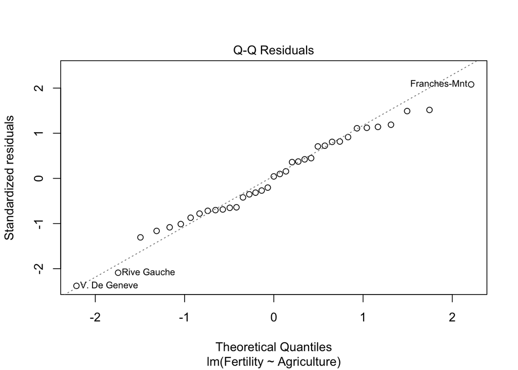

```r
# QQ plot (are the residuals normal?)
plot(mod1, which = 2)
```

Once you have a fitted model, you can pass it and some new data to `predict()` to generate predictions. The code below also calculates the [mean absolute error](https://en.wikipedia.org/wiki/Mean_absolute_error), [mean squared error](https://en.wikipedia.org/wiki/Mean_squared_error), and [mean absolute percent error](https://en.wikipedia.org/wiki/Mean_absolute_percentage_error), common error metrics used in regression problems.

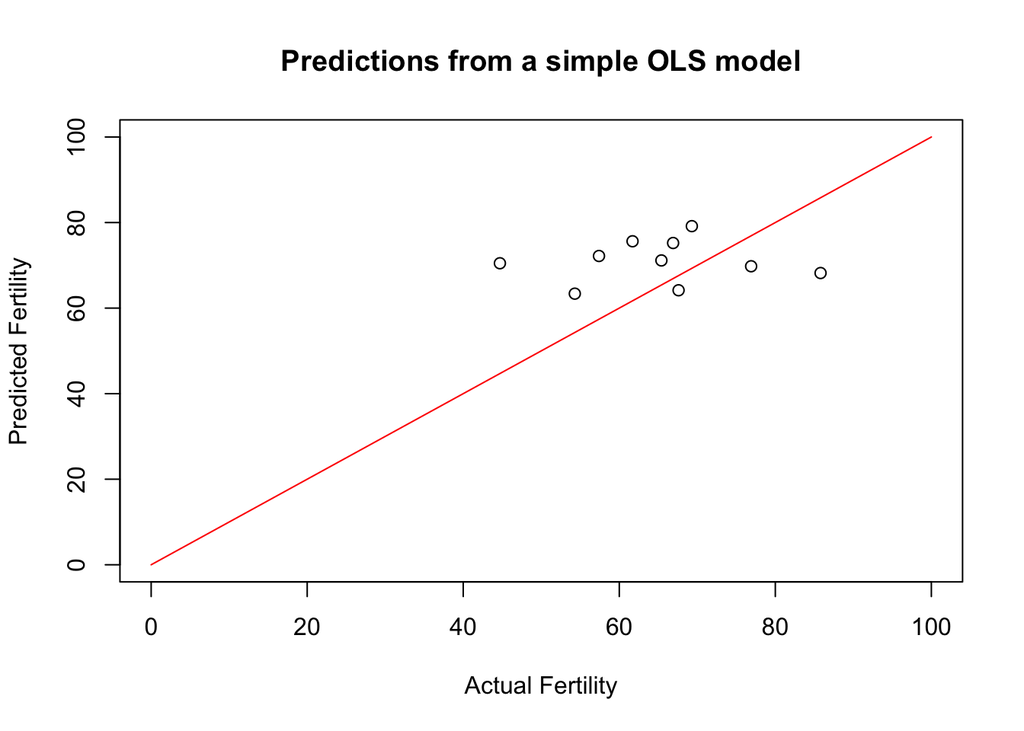

```r
# Check how well our model does on the held-out data
preds <- predict(mod1, newdata = swissTestDF)
errors <- swissTestDF$Fertility - preds

MAE   <- mean(abs(errors))
MSE   <- mean(errors^2)
MAPE  <- 100 * mean(abs(errors) / swissTestDF$Fertility)

# Actuals vs. Preds plot
plot(
    x = swissTestDF$Fertility
    , y = preds
    , xlab = "Actual Fertility"
    , ylab = "Predicted Fertility"
    , main = "Predictions from a simple OLS model"
    , ylim = c(0, 100)
    , xlim = c(0, 100)
)
lines(x = 0:100, y = 0:100, col = "red")
```

## Wrap Parts of Your Pipeline in Functions

The error metric calculations and plotting we just did seem general enough to apply to other models of this phenomenon. Since we could reuse the code for other models, we should just wrap it in a function so it’s easy to call downstream.

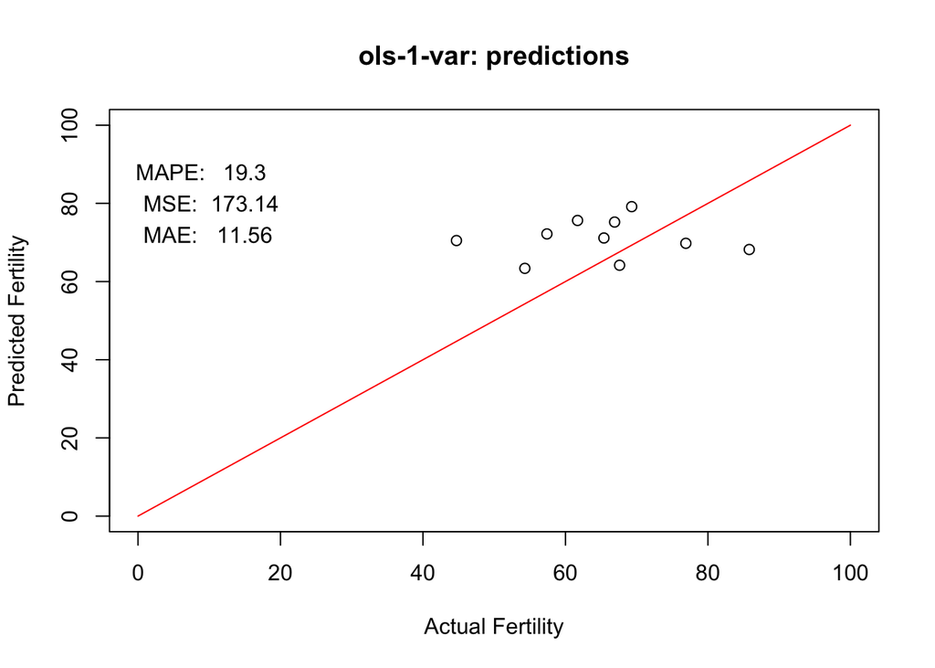

```
## $pred
## ValdeTravers      Yverdon   Neuveville         Orbe      Aubonne    La Vallee
##     64.16843     71.14260     69.78400     72.18419     75.21841     63.37592
##      Moutier  Rive Droite    Entremont     Cossonay
##     68.19896     70.48594     79.15836     75.62599
##
## $MAE
## [1] 11.564
##
## $MSE
## [1] 173.1363
##
## $MAPE
## [1] 19.30123
```

```r
# Before moving on...lets wrap that pipeline in a function
EvaluateModel <- function(model, testDF, modelName) {
    # Check how well our model does on the held-out data
    preds <- predict(model, newdata = testDF)
    errors <- testDF$Fertility - preds

    MAE   <- mean(abs(errors))
    MSE   <- mean(errors^2)
    MAPE  <- 100 * mean(abs(errors) / testDF$Fertility)

    # Actuals vs. Preds plot
    plot(
        x = testDF$Fertility
        , y = preds
        , xlab = "Actual Fertility"
        , ylab = "Predicted Fertility"
        , main = paste0(modelName, ": predictions")
        , ylim = c(0, 100)
        , xlim = c(0, 100)
    )

    # Add a 45-degree line
    lines(x = 0:100, y = 0:100, col = "red")

    # add error metrics
    text(x = rep(5, 3), y = c(72, 80, 88), labels = c("MAE: ", "MSE: ", "MAPE: "))
    text(x = rep(15, 3), y = c(72, 80, 88), labels = round(c(MAE, MSE, MAPE), 2))

    # Give back the preds in case user wants to do something customized
    return(list(
        pred = preds
        , MAE = MAE
        , MSE = MSE
        , MAPE = MAPE
    ))
}

EvaluateModel(
    model = mod1
    , testDF = swissTestDF
    , modelName = "ols-1-var"
)
```

## OLS with Multiple RHS Variables

To add more variables to a model in R, you have to use formula notation.

```r
# Fit
mod2 <- lm(
    Fertility ~ Education + Infant.Mortality + Examination_above_median
    , data = swiss
)

# Predict + Evaluate
regPreds2 <- EvaluateModel(
    mod2
    , testDF = swissTestDF
    , modelName = "Expanded OLS"
)
```

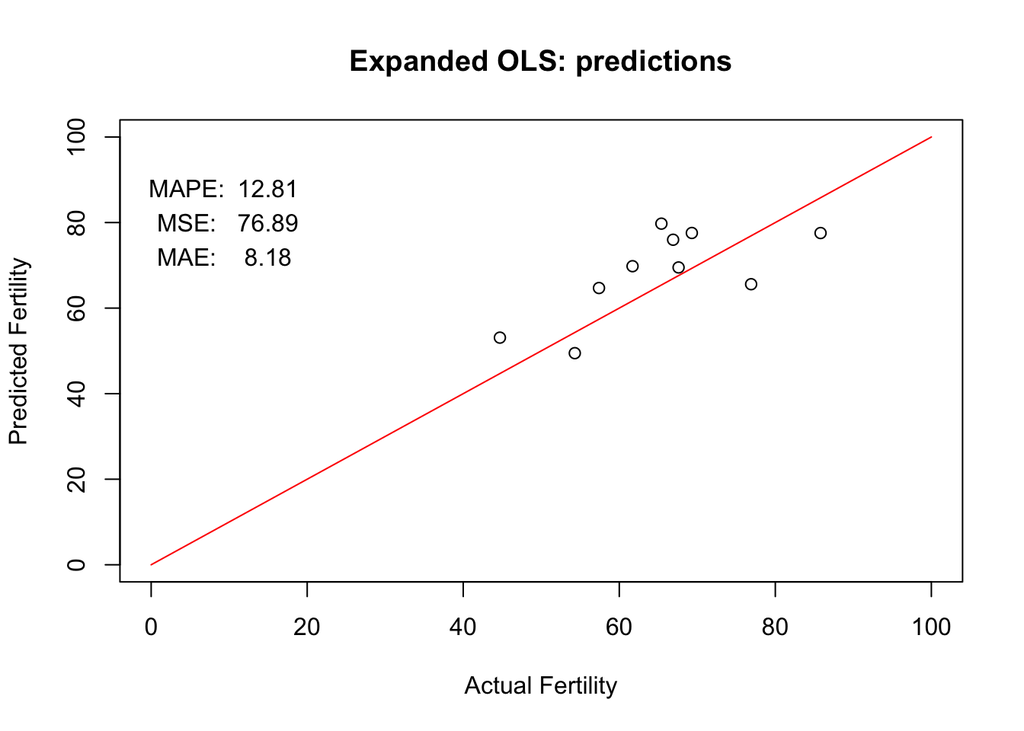

## Regression Trees

Linear regressions are powerful tools, but there are certain classes of complex relationships that they are unable to express and therefore unable to “learn” when trained on data.

Regression Trees are one tool used to fit non-linear functions. They recursively partition the dataset, trying to find “local” models of subsets of the data which, together, provide a better fit than the single “global” OLS model we’re used to fitting.

The details of tree-based learning are outside the scope of this class, but I encourage you to check out [A Visual Introduction to Machine Learning](http://www.r2d3.us/visual-intro-to-machine-learning-part-1/) to at least get the general intuition behind this and other ML techniques.

```r
library(rpart)

# Fit
treeMod <- rpart::rpart(Fertility ~ ., data = swiss)

# Evaluate
dtPreds <- EvaluateModel(
    treeMod
    , swissTestDF
    , "Decision Tree"
)
```

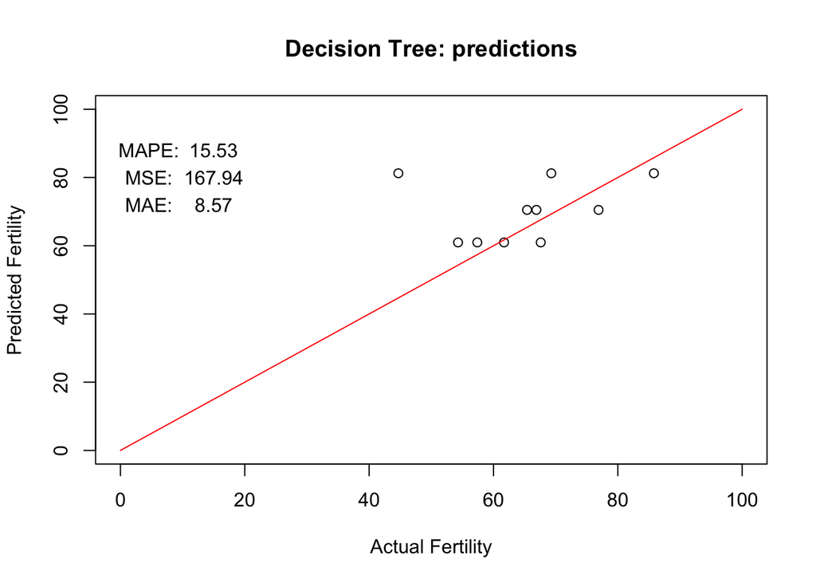

You can walk through the tree with this awesome package called `rattle`. This package can be [super hard to build](https://gist.github.com/sebkopf/9405675)… if you run into any issues, there are lots of nice options available via the [rpart.plot package](https://cran.r-project.org/web/packages/rpart.plot/rpart.plot.pdf).

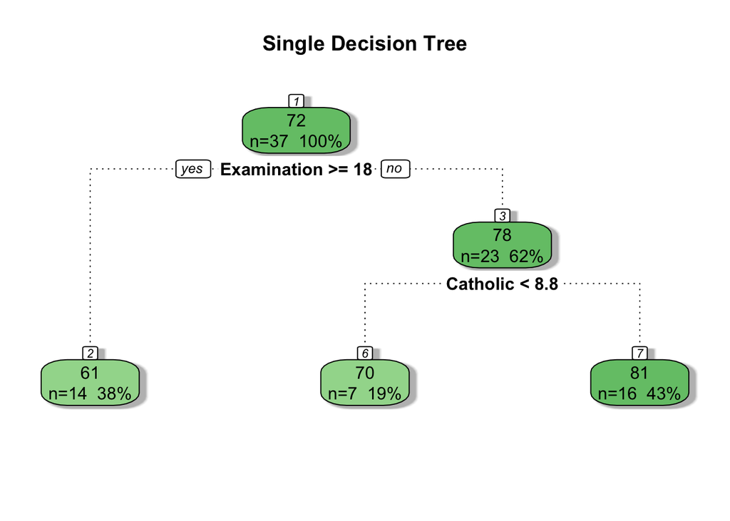

```r
# Plot the tree
rattle::fancyRpartPlot(
    treeMod
    , main = "Single Decision Tree"
    , sub = ""
)
```

## Random Forests

For larger datasets than the one we’re working with in this exercise, you may find that a single decision tree is not expressive enough or that one strong signal overpowers all the other variables.

To correct for this, you might use a “forest” of decision trees. The implementation details are outside the scope of this course: see [Leo Breiman’s excellent site](https://www.stat.berkeley.edu/~breiman/RandomForests/cc_home.htm) if you’re curious in learning more about this algorithm.

I only mention the random forest here to demonstrate how easy it is to fit and predict with complex statistical models in R.

```r
library(randomForest)

# Fit
rfMod <- randomForest::randomForest(
    Fertility ~ .
    , data = swiss
    , ntree = 50
    , do.trace = TRUE
)
```

```
##      |      Out-of-bag   |
## Tree |      MSE  %Var(y) |
##    1 |    182.9   119.94 |
##    2 |    162.2   106.33 |
##    3 |    128.9    84.48 |
##    4 |    116.8    76.60 |
##    5 |      115    75.37 |
##    6 |    125.3    82.17 |
##    7 |    112.7    73.91 |
##    8 |    110.1    72.18 |
##    9 |    102.4    67.11 |
##   10 |    109.8    71.96 |
##   11 |    105.5    69.18 |
##   12 |    101.8    66.74 |
##   13 |    91.23    59.81 |
```

[output cut: 37 more lines]

```r
# Evaluate
rfPreds <- EvaluateModel(
  model = rfMod
  , testDF = swissTestDF
  , modelName = "Random Forest (ntree=50)"
)
```

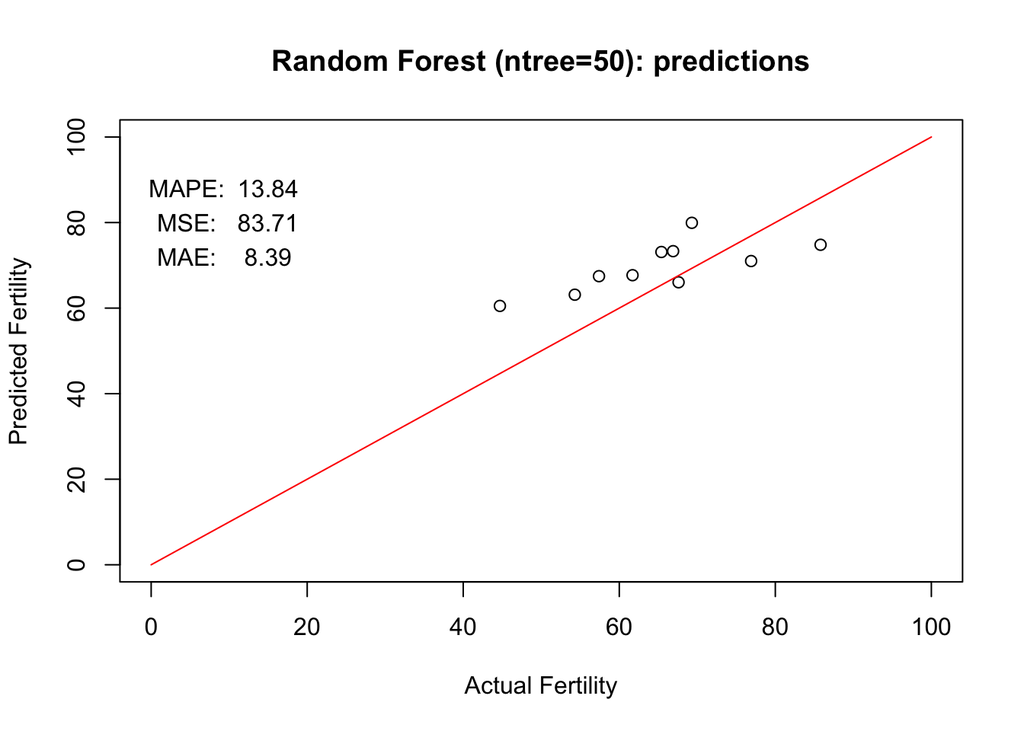